# Reproducible Research Course Project 1

Prashant

3/29/2022

## Introduction

It is now possible to collect a large amount of data about personal movement using activity monitoring devices such as a Fitbit, Nike Fuelband, or Jawbone Up. These type of devices are part of the “quantified self” movement – a group of enthusiasts who take measurements about themselves regularly to improve their health, to find patterns in their behavior, or because they are tech geeks. But these data remain under-utilized both because the raw data are hard to obtain and there is a lack of statistical methods and software for processing and interpreting the data.

This assignment makes use of data from a personal activity monitoring device. This device collects data at 5 minute intervals through out the day. The data consists of two months of data from an anonymous individual collected during the months of October and November, 2012 and include the number of steps taken in 5 minute intervals each day.

The data for this assignment can be downloaded from the course web site:

- Dataset: [Activity monitoring data](https://d396qusza40orc.cloudfront.net/repdata%2Fdata%2Factivity.zip)

The variables included in this dataset are:

steps: Number of steps taking in a 5-minute interval (missing values are coded as 𝙽𝙰)  
date: The date on which the measurement was taken in YYYY-MM-DD format  
interval: Identifier for the 5-minute interval in which measurement was taken  
The dataset is stored in a comma-separated-value (CSV) file and there are a total of 17,568 observations in this dataset.

## Loading and preprocessing the data

Unzip data to obtain a csv file.

```r
library(dplyr)
```

```r
library(ggplot2)
fileUrl <- "https://d396qusza40orc.cloudfront.net/repdata%2Fdata%2Factivity.zip"
download.file(fileUrl, destfile = paste0(getwd(), '/repdata%2Fdata%2Factivity.zip'), method = "curl")
unzip("repdata%2Fdata%2Factivity.zip",exdir = "data")
```

Reading csv data.

```r
df <- read.csv("activity.csv")
head(df, 10)
```

|  | steps | date | interval |
| --- | --- | --- | --- |
| 1 | NA | 2012-10-01 | 0 |
| 2 | NA | 2012-10-01 | 5 |
| 3 | NA | 2012-10-01 | 10 |
| 4 | NA | 2012-10-01 | 15 |
| 5 | NA | 2012-10-01 | 20 |
| 6 | NA | 2012-10-01 | 25 |
| 7 | NA | 2012-10-01 | 30 |
| 8 | NA | 2012-10-01 | 35 |
| 9 | NA | 2012-10-01 | 40 |
| 10 | NA | 2012-10-01 | 45 |

## Total number of steps taken per day

Transforming the data into a suitable format and calculating number of steps taken per day.

```r
edit_df <- df %>% group_by(date) %>% summarise(steps = sum(steps))
head(edit_df, 10)
```

| date | steps |
| --- | --- |
| 2012-10-01 | NA |
| 2012-10-02 | 126 |
| 2012-10-03 | 11352 |
| 2012-10-04 | 12116 |
| 2012-10-05 | 13294 |
| 2012-10-06 | 15420 |
| 2012-10-07 | 11015 |
| 2012-10-08 | NA |
| 2012-10-09 | 12811 |
| 2012-10-10 | 9900 |

Making a histogram of the total number of steps taken each day.

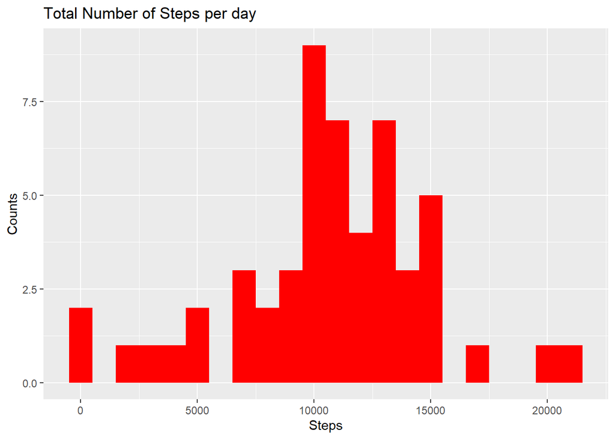

```r
ggplot(edit_df, aes(x = steps)) +
  geom_histogram(fill = "red", binwidth = 1000) +
  labs(title = "Total Number of Steps per day", x = "Steps", y = "Counts")
```

Calculating and reporting the mean of the total number of steps taken per day

```r
mean(edit_df$steps, na.rm = TRUE)
```

```
## [1] 10766.19
```

Calculating and reporting the median of the total number of steps taken per day

```r
median(edit_df$steps, na.rm = TRUE)
```

```
## [1] 10765
```

## Average daily activity pattern

Making a time series plot (i.e. `𝚝𝚢𝚙𝚎 = "𝚕"`) of the 5-minute interval (x-axis) and the average number of steps taken, averaged across all days (y-axis)

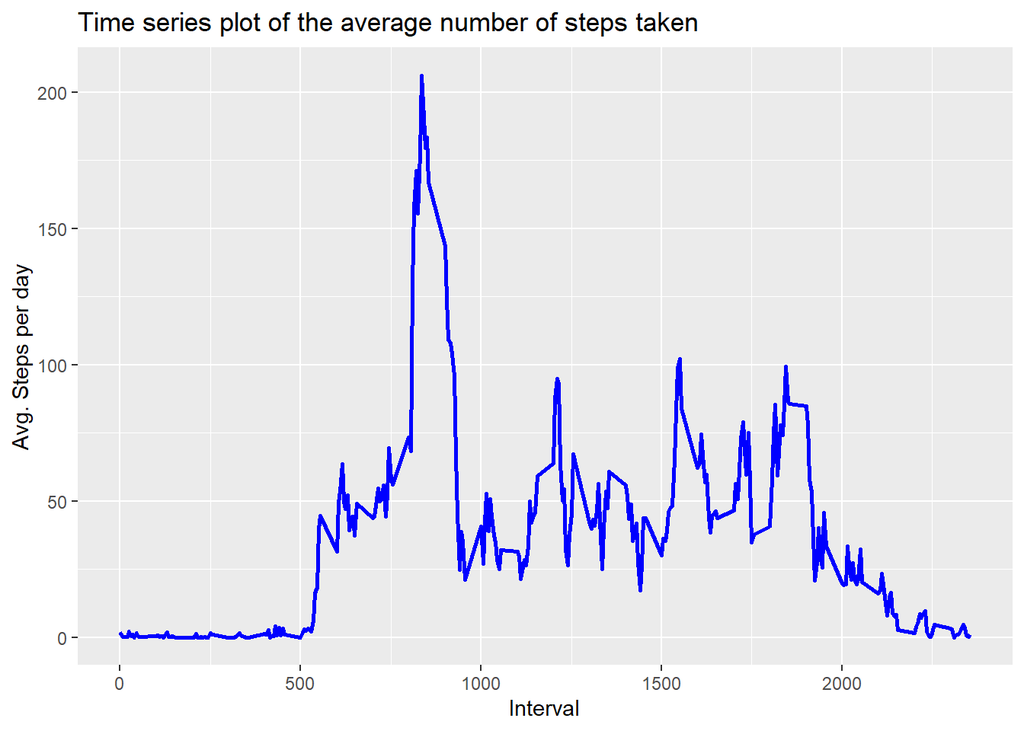

```r
df_interval <- df %>% group_by(interval) %>% summarise(steps = mean(steps, na.rm = TRUE))

ggplot(df_interval , aes(x = interval , y = steps)) +
  geom_line(color="blue", size=1) +
  labs(title = "Time series plot of the average number of steps taken", x = "Interval", y = "Avg. Steps per day")
```

Finding the 5-minute interval which contains the maximum number of steps

```r
df_interval[which(df_interval$steps == max(df_interval$steps)), ]$interval
```

```
## [1] 835
```

## Imputing missing values

Calculating the total number of missing values in the dataset:

```r
nrow(df[is.na(df$steps), ])
```

```
## [1] 2304
```

Choosing to replace all missing values with mean of the `steps` column

```r
# Filling in missing values with mean of dataset.
df[is.na(df$steps), "steps"] <- mean(df$steps, na.rm = TRUE)
```

Creating a new dataset that is equal to the original dataset but with the missing data filled in.

```r
write.csv(x = df, file = "newdata.csv", quote = FALSE)
```

```r
# total number of steps taken per day
edit_df2 <- df %>% group_by(date) %>% summarise(steps = sum(steps))
```

Calculating and reporting the mean of the total number of steps taken per day

```r
mean(edit_df2$steps, na.rm = TRUE)
```

```
## [1] 10766.19
```

Calculating and reporting the median of the total number of steps taken per day

```r
median(edit_df2$steps, na.rm = TRUE)
```

```
## [1] 10766.19
```

Summarizing Means and Medians to show how much these values differ before and after imputation:

```r
# mean and median total number of steps taken per day
def <- matrix(c(mean(edit_df2$steps, na.rm = TRUE), median(edit_df2$steps, na.rm = TRUE), mean(edit_df$steps, na.rm = TRUE), median(edit_df$steps, na.rm = TRUE)),ncol=2,byrow=TRUE)

colnames(def) <- c("Mean","Median")
rownames(def) <- c("Without Na", "With Na")

def
```

```
##                Mean   Median
## Without Na 10766.19 10766.19
## With Na    10766.19 10765.00
```

Making a histogram of the total number of steps taken each day

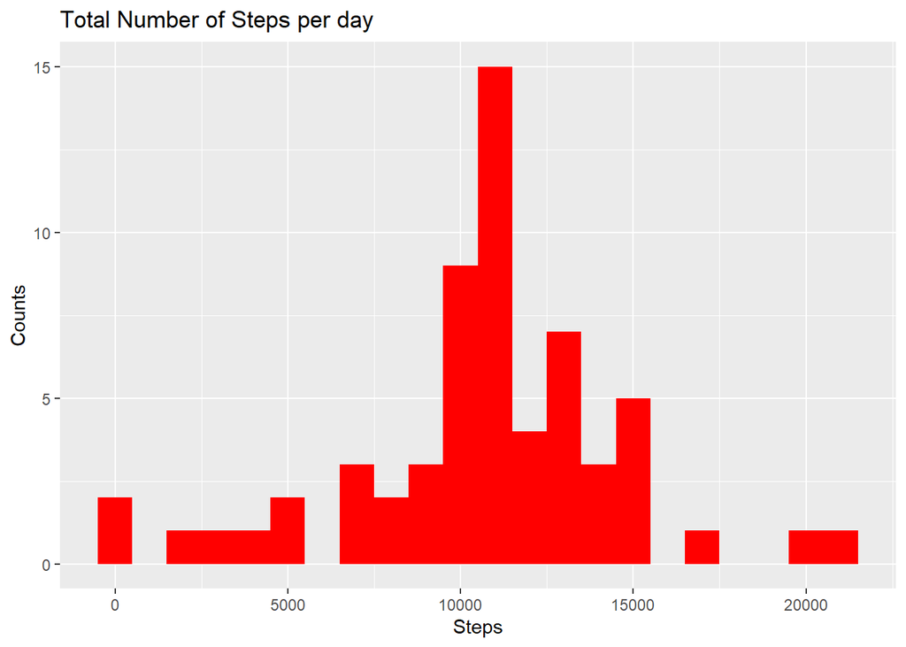

```r
ggplot(edit_df2, aes(x = steps)) + geom_histogram(fill = "red", binwidth = 1000) + labs(title = "Total Number of Steps per day", x = "Steps", y = "Counts")
```

Comparing this histogram with the histogram made before imputation, there is a difference noticed in both the plots.  
The histogram made after imputation has more counts than the one made before imputation.

## Differences in activity patterns between weekdays and weekends

Creating a new factor variable in the dataset with two levels – `weekday` and `weekend` indicating whether a given date is a weekday or weekend day.

```r
# Just recreating activityDT from scratch then making the new factor variable. (No need to, just want to be clear on what the entire process is.)
df[ , "date"] <- as.POSIXct(df$date, format = "%Y-%m-%d")
df[, "Day of the Week"] <- weekdays(x = df$date)

days <- c("Monday", "Tuesday", "Wednesday", "Thursday", "Friday")
df[, "check"] <- df[, "Day of the Week"] %in% days
df[df$check == TRUE, "weekday_or_weekend"] <- "weekday"
df[df$check == FALSE, "weekday_or_weekend"] <- "weekend"

head(df)
```

|  | steps | date | interval | Day of the Week | check | weekday_or_weekend |
| --- | --- | --- | --- | --- | --- | --- |
| 1 | 37.3826 | 2012-10-01 | 0 | Monday | TRUE | weekday |
| 2 | 37.3826 | 2012-10-01 | 5 | Monday | TRUE | weekday |
| 3 | 37.3826 | 2012-10-01 | 10 | Monday | TRUE | weekday |
| 4 | 37.3826 | 2012-10-01 | 15 | Monday | TRUE | weekday |
| 5 | 37.3826 | 2012-10-01 | 20 | Monday | TRUE | weekday |
| 6 | 37.3826 | 2012-10-01 | 25 | Monday | TRUE | weekday |

Making a panel plot containing a time series plot (i.e. `𝚝𝚢𝚙𝚎 = "𝚕"`) of the 5-minute interval (x-axis) and the average number of steps taken, averaged across all weekday days or weekend days (y-axis).

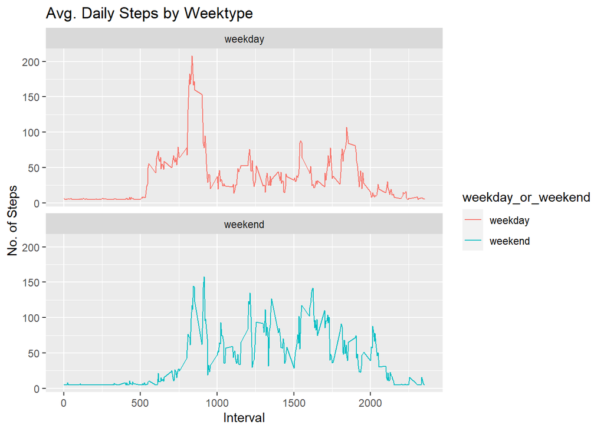

```r
df_interval2 <- df %>% group_by(interval, weekday_or_weekend) %>% summarise(steps = mean(steps, na.rm = TRUE), .groups = "drop")

ggplot(df_interval2 , aes(x = interval , y = steps, color=weekday_or_weekend)) + geom_line() + labs(title = "Avg. Daily Steps by Weektype", x = "Interval", y = "No. of Steps") + facet_wrap(~weekday_or_weekend , ncol = 1, nrow=2)
```